# Introduction to Machine Learning - Part 3

K-means Clustering

Gladstone Bioinformatics Core

2026-01-06

# Introduction to K-means Clustering

## Supervised vs Unsupervised Learning

In **Part 2**, we worked with **supervised learning** (Random Forest): - We had labeled data (COVID positive/negative) - Goal: Predict labels for new data

Now, we’ll explore **unsupervised learning**: - No labels! - Goal: Find hidden patterns/groups in the data

```
SUPERVISED                    UNSUPERVISED
===========                   ============
Training: 🔴🔴🔵🔵            Training: ⚪⚪⚪⚪
(with labels)                 (no labels)
           ↓                            ↓
Model learns                  Algorithm finds
decision boundary             natural groupings
           ↓                            ↓
Predict: 🔴 or 🔵             Group: A, B, or C
```

## How K-means Works

K-means groups data into K clusters by minimizing within-cluster variance:

```
Step 1: Initialize K centroids randomly

        ⚪ ⚪ ⚪        ★ (centroid 1)
        ⚪ ⚪
            ⚪ ⚪
                ⚪ ⚪   ★ (centroid 2)

Step 2: Assign each point to nearest centroid

        🔴 🔴 🔴        ★
        🔴 🔴
            🔵 🔵
                🔵 🔵   ★

Step 3: Update centroids (move to cluster mean)

        🔴 🔴 🔴
        🔴 ★🔴
            🔵 🔵
                🔵 ★🔵

Step 4: Repeat steps 2-3 until convergence
```

# Load Libraries and Data

```r
# Core libraries
library(tidyverse)
library(cluster)      # For clustering algorithms
library(factoextra)   # For visualization
library(ggplot2)

# Set seed for reproducibility
set.seed(123)
```

```r
# Load the cleaned dataset from Part 1
covid_ml <- read.csv("data/covid_ml_clean.csv")

cat("Dataset dimensions:", dim(covid_ml), "\n")
```

```
## Dataset dimensions: 3045 19
```

```r
head(covid_ml)
```

```
##   covid19_test_results temperature high_risk_exposure_occupation
## 1             Negative       37.20                             0
## 2             Negative       36.95                             0
## 3             Negative       37.00                             0
## 4             Negative       36.85                             0
## 5             Negative       37.10                             0
## 6             Negative       36.80                             0
##   high_risk_interactions labored_respiration rhonchi cough fever sob diarrhea
## 1                      1                   0       1     0     0   0        0
## 2                      1                   0       0     0     0   0        0
## 3                      0                   0       0     0     0   0        0
## 4                      0                   0       0     0     0   0        0
## 5                      0                   0       0     0     0   0        0
## 6                      0                   0       0     0     0   0        0
##   fatigue headache loss_of_smell loss_of_taste runny_nose muscle_sore
## 1       0        0             0             0          0           0
## 2       0        0             0             0          0           0
## 3       0        1             0             0          0           1
## 4       0        0             0             0          0           0
## 5       0        0             0             0          0           0
## 6       0        0             0             0          0           0
##   sore_throat wheezes cough_severity_encoded
## 1           0       1                      0
## 2           0       0                      0
## 3           0       0                      0
## 4           0       0                      0
## 5           0       0                      0
## 6           0       0                      0
```

# Prepare Data for K-means

## Important Considerations

⚠️ **K-means requirements:**

1. **Cannot handle missing values** - must impute or remove first (we did this in Part 1!)
2. **Uses Euclidean distance** - works best with numeric data
3. **Sensitive to scale** - must standardize features

## Select Features for Clustering

Since K-means is unsupervised, we’ll exclude the target variable:

```r
# For K-means, we'll use only numeric features
# We'll exclude the target variable (since it's unsupervised!)

cluster_data <- covid_ml %>%
  select(-covid19_test_results)  # Remove target

cat("Features for clustering:\n")
```

```
## Features for clustering:
```

```r
names(cluster_data)
```

```
##  [1] "temperature"                   "high_risk_exposure_occupation"
##  [3] "high_risk_interactions"        "labored_respiration"
##  [5] "rhonchi"                       "cough"
##  [7] "fever"                         "sob"
##  [9] "diarrhea"                      "fatigue"
## [11] "headache"                      "loss_of_smell"
## [13] "loss_of_taste"                 "runny_nose"
## [15] "muscle_sore"                   "sore_throat"
## [17] "wheezes"                       "cough_severity_encoded"
```

## Scale the Data

```r
# Scale all features
cluster_scaled <- scale(cluster_data)

# Verify scaling
cat("Scaled data - Column means (should be ~0):\n")
```

```
## Scaled data - Column means (should be ~0):
```

```r
round(colMeans(cluster_scaled), 10)[1:5]
```

```
##                   temperature high_risk_exposure_occupation
##                             0                             0
##        high_risk_interactions           labored_respiration
##                             0                             0
##                       rhonchi
##                             0
```

```r
cat("\nScaled data - Column SDs (should be ~1):\n")
```

```
##
## Scaled data - Column SDs (should be ~1):
```

```r
round(apply(cluster_scaled, 2, sd), 10)[1:5]
```

```
##                   temperature high_risk_exposure_occupation
##                             1                             1
##        high_risk_interactions           labored_respiration
##                             1                             1
##                       rhonchi
##                             1
```

# Choosing K: The Elbow Method

The hardest part of K-means: **How many clusters?**

## The Elbow Method

We plot **within-cluster sum of squares (WSS)** vs K: - WSS measures how compact the clusters are - As K increases, WSS always decreases - Look for the “elbow” where the rate of decrease slows

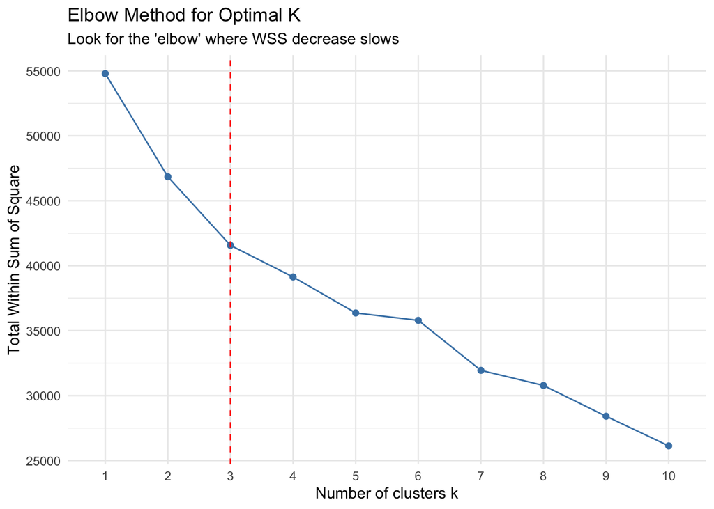

```r
# Calculate WSS for different K values
fviz_nbclust(cluster_scaled, kmeans, method = "wss", k.max = 10) +
  geom_vline(xintercept = 3, linetype = "dashed", color = "red") +
  labs(title = "Elbow Method for Optimal K",
       subtitle = "Look for the 'elbow' where WSS decrease slows") +
  theme_minimal()
```

## Silhouette Method

Another approach: measure how similar points are to their own cluster vs other clusters.

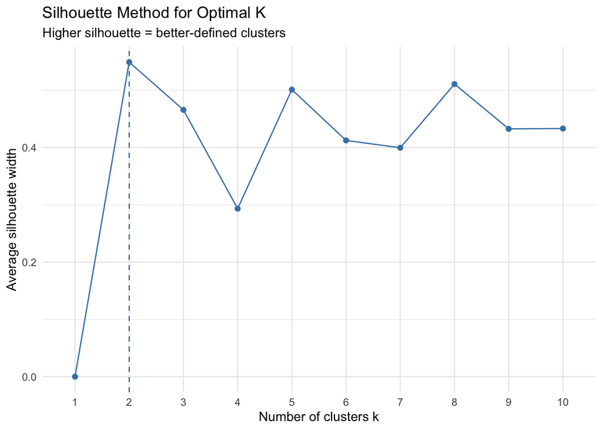

```r
# Silhouette method
fviz_nbclust(cluster_scaled, kmeans, method = "silhouette", k.max = 10) +
  labs(title = "Silhouette Method for Optimal K",
       subtitle = "Higher silhouette = better-defined clusters") +
  theme_minimal()
```

# Run K-means Clustering

Based on our analysis, let’s try K = 3 (you can adjust based on the elbow plot):

```r
# Run K-means with K = 3
k <- 3

kmeans_result <- kmeans(
  cluster_scaled,
  centers = k,
  nstart = 50,        # Try 50 random starts, keep best
  iter.max = 100,     # Maximum iterations
  algorithm = "Lloyd" # Classic K-means algorithm
)

# View results
cat("K-means Results:\n")
```

```
## K-means Results:
```

```r
cat("================\n")
cat("Number of clusters:", k, "\n")
```

```
## Number of clusters: 3
```

```r
cat("Cluster sizes:", kmeans_result$size, "\n")
```

```
## Cluster sizes: 190 2484 371
```

```r
cat("Within-cluster sum of squares:", round(kmeans_result$tot.withinss, 2), "\n")
```

```
## Within-cluster sum of squares: 41555.52
```

```r
cat("Between/Total SS ratio:", round(kmeans_result$betweenss / kmeans_result$totss * 100, 1), "%\n")
```

```
## Between/Total SS ratio: 24.2 %
```

## Understanding the Output

```r
# Cluster assignments
head(kmeans_result$cluster, 20)
```

```
##  [1] 1 2 2 2 2 2 2 2 2 2 3 2 1 2 2 2 2 3 1 2
```

```r
# Cluster centers (on scaled data)
cat("\nCluster Centers (scaled):\n")
```

```
##
## Cluster Centers (scaled):
```

```r
round(kmeans_result$centers[, 1:6], 3)
```

```
##   temperature high_risk_exposure_occupation high_risk_interactions
## 1      -0.159                        -0.075                 -0.008
## 2      -0.008                        -0.053                 -0.049
## 3       0.137                         0.391                  0.331
##   labored_respiration rhonchi  cough
## 1              -0.031   3.876 -0.190
## 2              -0.019  -0.258 -0.238
## 3               0.140  -0.258  1.694
```

# Visualize Clusters

## PCA-based Visualization

Since we have many features, we’ll use PCA to reduce to 2D for visualization:

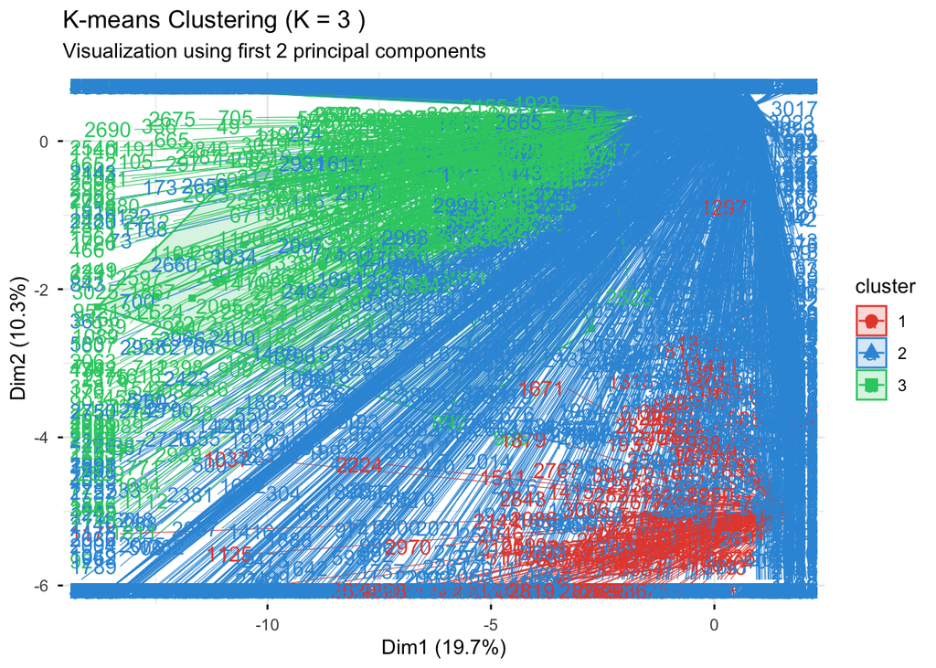

```r
# Visualize clusters (uses PCA internally)
fviz_cluster(
  kmeans_result,
  data = cluster_scaled,
  palette = c("#e74c3c", "#3498db", "#2ecc71"),
  ellipse.type = "convex",
  star.plot = TRUE,
  repel = TRUE,
  ggtheme = theme_minimal()
) +
  labs(title = paste("K-means Clustering (K =", k, ")"),
       subtitle = "Visualization using first 2 principal components")
```

## Cluster Profiles

Let’s understand what makes each cluster different:

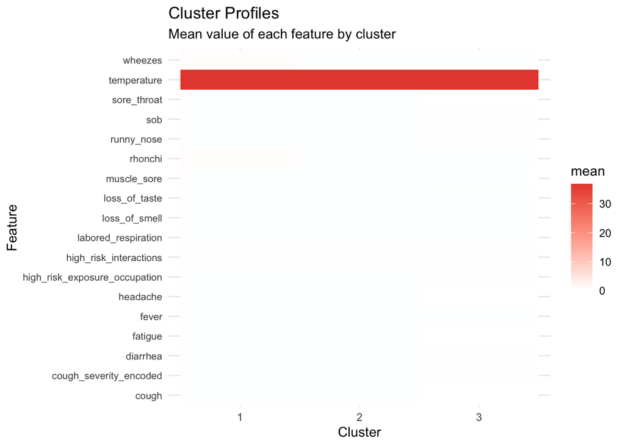

```r
# Add cluster assignment to original data
covid_clustered <- covid_ml %>%
  mutate(cluster = as.factor(kmeans_result$cluster))

# Calculate mean of each feature by cluster
cluster_profiles <- covid_clustered %>%
  group_by(cluster) %>%
  summarise(across(where(is.numeric), mean)) %>%
  pivot_longer(-cluster, names_to = "feature", values_to = "mean")

# Plot heatmap of cluster profiles
ggplot(cluster_profiles, aes(x = cluster, y = feature, fill = mean)) +
  geom_tile() +
  scale_fill_gradient2(low = "#3498db", mid = "white", high = "#e74c3c", midpoint = 0.5) +
  labs(title = "Cluster Profiles",
       subtitle = "Mean value of each feature by cluster",
       x = "Cluster",
       y = "Feature") +
  theme_minimal() +
  theme(axis.text.y = element_text(size = 8))
```

## Compare Clusters with COVID Status

Even though K-means is unsupervised, we can check if clusters correspond to COVID status:

```r
# Cross-tabulate clusters with COVID status
cluster_covid_table <- table(
  Cluster = covid_clustered$cluster,
  COVID_Status = covid_clustered$covid19_test_results
)

print(cluster_covid_table)
```

```
##        COVID_Status
## Cluster Negative Positive
##       1      186        4
##       2     2453       31
##       3      338       33
```

```r
# Proportions
cat("\nProportions within each cluster:\n")
```

```
##
## Proportions within each cluster:
```

```r
prop.table(cluster_covid_table, margin = 1)
```

```
##        COVID_Status
## Cluster   Negative   Positive
##       1 0.97894737 0.02105263
##       2 0.98752013 0.01247987
##       3 0.91105121 0.08894879
```

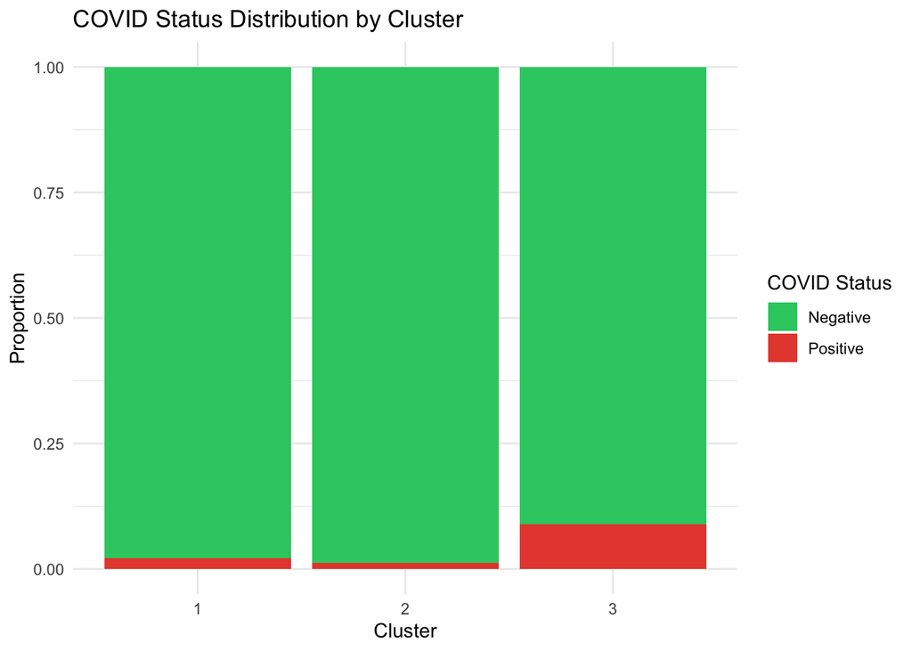

```r
# Visualize
ggplot(covid_clustered, aes(x = cluster, fill = covid19_test_results)) +
  geom_bar(position = "fill") +
  scale_fill_manual(values = c("Negative" = "#2ecc71", "Positive" = "#e74c3c")) +
  labs(title = "COVID Status Distribution by Cluster",
       x = "Cluster",
       y = "Proportion",
       fill = "COVID Status") +
  theme_minimal()
```

# Evaluating Cluster Quality

## Silhouette Analysis

Silhouette values range from -1 to 1: - **Near 1**: Point is well-matched to its cluster - **Near 0**: Point is on the border between clusters - **Negative**: Point might be in wrong cluster

```r
# Calculate silhouette for K-means result
sil <- silhouette(kmeans_result$cluster, dist(cluster_scaled))

# Summary
cat("Average Silhouette Width:", round(mean(sil[, "sil_width"]), 3), "\n")
```

```
## Average Silhouette Width: 0.484
```

```
##   cluster size ave.sil.width
## 1       1  190          0.54
## 2       2 2484          0.57
## 3       3  371         -0.14
```

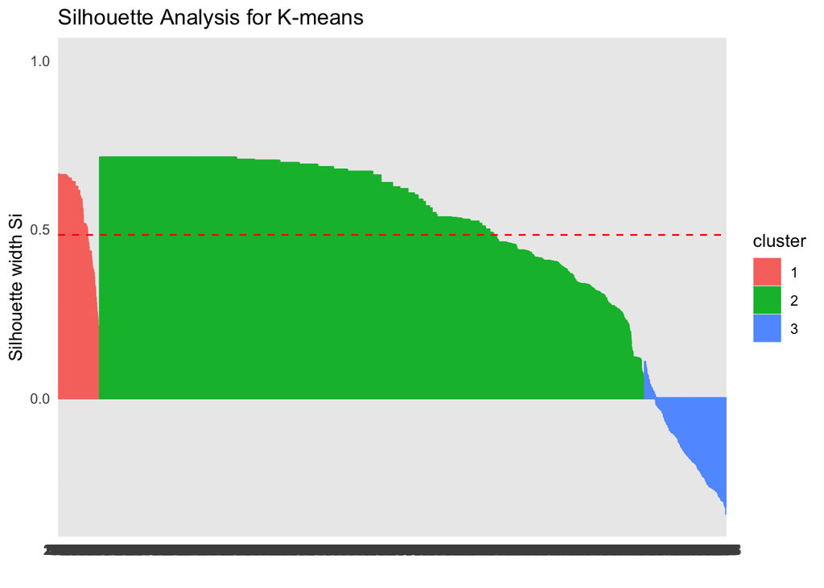

```r
# Plot
fviz_silhouette(sil) +
  labs(title = "Silhouette Analysis for K-means") +
  theme_minimal()
```

# Summary

## What We Learned

1. ✅ **K-means** is an unsupervised algorithm that groups data into K clusters
2. ✅ **Choosing K** - use elbow method or silhouette analysis
3. ✅ **Data preparation** - must handle missing values and scale features
4. ✅ **Visualization** - PCA helps visualize high-dimensional clusters
5. ✅ **Evaluation** - use silhouette scores to assess cluster quality

## When to Use K-means

- ✅ Numeric, continuous features
- ✅ Expected spherical/compact clusters
- ✅ Large datasets (efficient algorithm)
- ✅ Know approximate number of clusters

# Workshop Summary

## What We Covered

| Part | Topic | Type | Key Concepts |
| --- | --- | --- | --- |
| 1 | Data Preprocessing | Preparation | Missing values, encoding, scaling |
| 2 | Random Forest | Supervised | Ensemble, feature importance, OOB |
| 3 | K-means | Unsupervised | Clustering, elbow method, silhouette |

## Key Takeaways

1. **Always explore and clean your data first!**
2. **Understand your algorithm’s requirements** (scaling, missing data, data types)
3. **Use cross-validation** to avoid overfitting (supervised learning)
4. **Evaluate appropriately** - accuracy isn’t everything!
5. **No algorithm is universally best** - choose based on your data and goals

## Resources for Further Learning

- [An Introduction to Statistical Learning](https://www.statlearning.com/) - Free textbook
- [caret package documentation](https://topepo.github.io/caret/)
- [tidymodels](https://www.tidymodels.org/) - Modern ML framework in R
- [scikit-learn](https://scikit-learn.org/) - Python ML library with great documentation